# Apply OE

Apply OE is the built-in end-to-end atmospheric correction pipeline, and is the easiest way to run Isofit. Apply OE is run via a command line interface (CLI) tool accessed with a terminal call:

```
isofit apply_oe --help
```

The function docstring is printed when this command is run within a terminal window, and acts as a guide for how to run the function.

```python
from isofit.utils.apply_oe import apply_oe

print(apply_oe.__doc__)
```

from isofit.utils.apply_oe import apply_oe print(apply_oe.__doc__)

```
    Applies OE over a flightline using a radiative transfer engine. This executes
    ISOFIT in a generalized way, accounting for the types of variation that might be
    considered typical.

    Observation (obs) and location (loc) files are used to determine appropriate
    geometry lookup tables and provide a heuristic means of determining atmospheric
    water ranges.

    Parameters
    ----------
    input_radiance : str
        Radiance data cube. Expected to be ENVI format
    input_loc : str
        Location data cube of shape (Lon, Lat, Elevation). Expected to be ENVI format
    input_obs : str
        Observation data cube of shape:
            (path length, to-sensor azimuth, to-sensor zenith,
            to-sun azimuth, to-sun zenith, phase,
            slope, aspect, cosine i, UTC time)
        Expected to be ENVI format
    working_directory : str
        Directory to stage multiple outputs, will contain subdirectories
    sensor : str
        The sensor used for acquisition, will be used to set noise and datetime
        settings
    surface_path : str
        Path to surface model or json dict of surface model configuration
    copy_input_files : bool, default=False
        Flag to choose to copy input_radiance, input_loc, and input_obs locally into
        the working_directory
    modtran_path : str, default=None
        Location of MODTRAN utility. Alternately set with `MODTRAN_DIR` environment
        variable
    wavelength_path : str, default=None
        Location to get wavelength information from, if not specified the radiance
        header will be used
    surface_category : str, default="multicomponent_surface"
        The type of ISOFIT surface priors to use.  Default is multicomponent_surface
    aerosol_climatology_path : str, default=None
        Specific aerosol climatology information to use in MODTRAN
```

[output cut: 100 more lines]

```
        with one number per instrument channel.
    terrain_style : str, default=dem
        Flag to set the terrain style.  dem uses provided obs values, flat sets the surface to the spheroid

    References
    ----------
    D.R. Thompson, A. Braverman,P.G. Brodrick, A. Candela, N. Carbon, R.N. Clark,D. Connelly, R.O. Green, R.F.
    Kokaly, L. Li, N. Mahowald, R.L. Miller, G.S. Okin, T.H.Painter, G.A. Swayze, M. Turmon, J. Susilouto, and
    D.S. Wettergreen. Quantifying Uncertainty for Remote Spectroscopy of Surface Composition. Remote Sensing of
    Environment, 2020. doi: https://doi.org/10.1016/j.rse.2020.111898.

    sRTMnet emulator:
    P.G. Brodrick, D.R. Thompson, J.E. Fahlen, M.L. Eastwood, C.M. Sarture, S.R. Lundeen, W. Olson-Duvall,
    N. Carmon, and R.O. Green. Generalized radiative transfer emulation for imaging spectroscopy reflectance
    retrievals. Remote Sensing of Environment, 261:112476, 2021.doi: 10.1016/j.rse.2021.112476.
```

The Apply OE function can leverage a large number of input parameters, but most are optional. The important inputs are the non-optional arguments:

`INPUT_RADIANCE` `INPUT_LOC` `INPUT_OBS` `WORKING_DIRECTORY` `SENSOR` and `--surface_path`.

#### `INPUT_RADIANCE`

The data is at-sensor radiance in units of $\mu W \, cm^{-2} \, nm^{-1} \, sr^{-1} $. You may leverage **isofit.core.units** module which offers many common conversions. The .hdr file should be used to store the wavelength and fwhm.

#### `INPUT_LOC`

1. **Longitude [degrees]**
   - Range is -180 to 180
2. **Latitude [degrees]**
   - Range is -90 to 90
3. **Elevation [meters]**
   - Above mean sea level

#### `INPUT_OBS`

Note: the names of the keys do not need to match exactly, only the order matters.

1. **Path length [meters]**
   - Defined as the slant path from the sensor to the surface
2. **To-sensor azimuth, $\phi_v$ [degrees]**
   - Ranges from 0-360, measured clockwise from north
3. **To-sensor zenith, $\theta_v$ [degrees]**
   - Ranges from 0-90, measured from zenith
4. **To-sun azimuth, $\phi_s$ [degrees]**
   - Ranges from 0-360, measured clockwise from north
5. **To-sun zenith, $\theta_s$ [degrees]**
   - Ranges from 0-90, measured from zenith
6. **Phase angle, $\xi$ [degrees]**
   - $cos(\xi) = cos(\theta_s) \, cos(\theta_v) \, + \, sin(\theta_s) \, sin(\theta_v) \, cos(\phi_s - \phi_v)$
   - $\xi = arccos(cos(\xi))$
7. **Slope, $S$ [degrees]**
   - Ranges from 0-90
8. **Aspect, $A$ [degrees]**
   - Ranges from 0-360, measured clockwise from north
9. **Cosine of the local solar illumination angle, $cos(i)$ [unitless]**
   - $cos(i) = cos(\theta_s) \, cos(S) \, + \, sin(\theta_s) \, sin(S) \, cos(\phi_s - A) $
10. **UTC time [decimal]**
    - Ranges from 0 - 24
11. **Earth-sun distance [AU]**
    - Astronomical Unit as a function of day of year

## How do you run Apply OE?

The script is run via the CLI. For example:

> `IC=$(isofit path examples)/image_cube/small` sets the environment variable `IC` to the output of the command `isofit path examples/image_cube/small`. This is just used to reuse the same output for multiple arguments. Depending on the user's isofit installation environment, this path may vary. This command ensures the correct path is retrieved

```
  IC=$(isofit path examples)/image_cube/small EX=$(isofit path examples)/image_cube/small \
  isofit apply_oe \
  $IC/ang20170323t202244_rdn_7000-7010 \
  $IC/ang20170323t202244_loc_7000-7010 \
  $IC/ang20170323t202244_obs_7000-7010 \
  $EX \
  ang \
  --surface_path $EX/configs/surface.json \
  --emulator_base $(isofit path srtmnet --key file) \
  --n_cores 10 \
  --presolve \
```

Here,

```
$IC/ang20170323t202244_rdn_7000-7010
$IC/ang20170323t202244_loc_7000-7010
$IC/ang20170323t202244_obs_7000-7010
```

are the radiance, location, and observational geometry files respectively. The `\` tells the CLI call to expect a multi-line input. The remaining two required parameters are `ang`, the sensor designation (AVIRIS-NG), and the `--surface_path` pointing to the surface configuration file which will be built at runtime.

The remaining arguments set Apply OE to run with:

1. `--emulator_base` points isofit to the location of the sRTMnet emulator to usse as the radiative transfer engine (RTE)
2. `--n_cores = 10` CPU cores
3. The `--presolve` algorithm to narrow down the water vapor retrievals

```python
# Alternatively, you can programatically call apply_oe. If you executed apply_oe via the command line above, do not run this
# We use the env object to retrieve the actual location of the ISOFIT extra dependencies instead of assuming where they could be
import os
import shutil

from isofit.utils.apply_oe import apply_oe
from isofit.data import env

output = env.path("examples", "image_cube", "small")

# Cleanup any previous runs; comment this out if you want to preserve a previous run's output
if (o := output / "output").exists():
    shutil.rmtree(o)

apply_oe(
    input_radiance    = str(env.path("examples", "image_cube", "small", "data", "ang20170323t202244_rdn_7000-7010")),
    input_loc         = str(env.path("examples", "image_cube", "small", "data", "ang20170323t202244_loc_7000-7010")),
    input_obs         = str(env.path("examples", "image_cube", "small", "data", "ang20170323t202244_obs_7000-7010")),
    working_directory = str(output),
    sensor            = "ang",
    surface_path      = str(env.path("examples", "image_cube", "small", "configs", "surface.json")),
    emulator_base     = str(env.path("srtmnet", key="srtmnet.file")),
    presolve          = True,
    n_cores           = os.cpu_count(),
)
```

# Alternatively, you can programatically call apply_oe. If you executed apply_oe via the command line above, do not run this # We use the env object to retrieve the actual location of the ISOFIT extra dependencies instead of assuming where they could be import os import shutil from isofit.utils.apply_oe import apply_oe from isofit.data import env output = env.path("examples", "image_cube", "small") # Cleanup any previous runs; comment this out if you want to preserve a previous run's output if (o := output / "output").exists(): shutil.rmtree(o) apply_oe( input_radiance = str(env.path("examples", "image_cube", "small", "data", "ang20170323t202244_rdn_7000-7010")), input_loc = str(env.path("examples", "image_cube", "small", "data", "ang20170323t202244_loc_7000-7010")), input_obs = str(env.path("examples", "image_cube", "small", "data", "ang20170323t202244_obs_7000-7010")), working_directory = str(output), sensor = "ang", surface_path = str(env.path("examples", "image_cube", "small", "configs", "surface.json")), emulator_base = str(env.path("srtmnet", key="srtmnet.file")), presolve = True, n_cores = os.cpu_count(), )

```
INFO:2026-05-20,17:38:40 || apply_oe.py:apply_oe() | Checking input data files...
```

```
INFO:2026-05-20,17:38:40 || apply_oe.py:apply_oe() | ...Data file checks complete
```

```
INFO:2026-05-20,17:38:40 || apply_oe.py:apply_oe() | Setting up files and directories....
```

```
INFO:2026-05-20,17:38:40 || template_construction.py:__init__() | Flightline ID: ang20170323t202244
```

```
INFO:2026-05-20,17:38:40 || template_construction.py:__init__() | no noise path found, proceeding without
```

```
INFO:2026-05-20,17:38:40 || apply_oe.py:apply_oe() | ...file/directory setup complete
```

```
INFO:2026-05-20,17:38:40 || apply_oe.py:apply_oe() | Using inversion windows: [[350.0, 1360.0], [1410, 1800.0], [1970.0, 2500.0]]
```

```
INFO:2026-05-20,17:38:40 || template_construction.py:get_wavelengths() | No wavelength file provided. Obtaining wavelength grid from ENVI header of radiance cube.
```

```
INFO:2026-05-20,17:38:40 || template_construction.py:get_wavelengths() | Wavelength units of nm inferred...converting to microns
```

```
INFO:2026-05-20,17:38:40 || template_construction.py:check_surface_model() | No surface model provided. Build new one using given config file.
```

```
0 ['/home/runner/work/isofit-tutorials/data/reflectance/surface_model_ucsb']
```

```
1 ['/home/runner/work/isofit-tutorials/data/reflectance/surface_model_ucsb']
```

```
2 ['/home/runner/work/isofit-tutorials/data/reflectance/surface_model_ucsb']
```

```
3 ['/home/runner/work/isofit-tutorials/data/reflectance/surface_model_ucsb']
```

```
4 ['/home/runner/work/isofit-tutorials/data/reflectance/surface_model_ucsb']
```

```
5 ['/home/runner/work/isofit-tutorials/data/reflectance/surface_model_ucsb']
6 ['/home/runner/work/isofit-tutorials/data/reflectance/surface_model_ucsb']
```

```
7 ['/home/runner/work/isofit-tutorials/data/reflectance/surface_model_ucsb']
```

```
INFO:2026-05-20,17:38:42 || apply_oe.py:apply_oe() | Observation means:
```

```
INFO:2026-05-20,17:38:42 || apply_oe.py:apply_oe() | Path (km): 20.716992087408016
```

```
INFO:2026-05-20,17:38:42 || apply_oe.py:apply_oe() | To-sensor azimuth (deg): 71.27130737250893
```

```
INFO:2026-05-20,17:38:42 || apply_oe.py:apply_oe() | To-sensor zenith (deg): 17.34528282852098
```

```
INFO:2026-05-20,17:38:42 || apply_oe.py:apply_oe() | To-sun azimuth (deg): 197.3237574125862
```

```
INFO:2026-05-20,17:38:42 || apply_oe.py:apply_oe() | To-sun zenith (deg): 32.45698605676816
```

```
INFO:2026-05-20,17:38:42 || apply_oe.py:apply_oe() | Relative to-sun azimuth (deg): 126.05245004007726
```

```
INFO:2026-05-20,17:38:42 || apply_oe.py:apply_oe() | Altitude (km): 19.808562728369008
```

```
INFO:2026-05-20,17:38:42 || apply_oe.py:apply_oe() | Pre-solve H2O grid: [0.2  0.76 1.33 1.89 2.46 3.02 3.59 4.15 4.71 5.28]
```

```
INFO:2026-05-20,17:38:42 || apply_oe.py:apply_oe() | Writing H2O pre-solve configuration file.
```

```
INFO:2026-05-20,17:38:42 || ini.py:toTemplate() | Saved converted json to: /home/runner/work/isofit-tutorials/isofit-tutorials/image_cube/small/config/ang20170323t202244_h2o.json.tmpl
```

```
INFO:2026-05-20,17:38:42 || apply_oe.py:apply_oe() | Run ISOFIT initial guess
```

[output not shown]

```
INFO:2026-05-20,17:38:42 || configs.py:create_new_config() | Loading config file: /home/runner/work/isofit-tutorials/isofit-tutorials/image_cube/small/config/ang20170323t202244_h2o.json
```

```
INFO:2026-05-20,17:38:42 || configs.py:get_config_errors() | Checking config sections for configuration issues
```

```
INFO:2026-05-20,17:38:42 || configs.py:get_config_errors() | Configuration file checks complete, no errors found.
```

```
2026-05-20 17:38:48,885	INFO worker.py:2012 -- Started a local Ray instance.
```

```
INFO:2026-05-20,17:38:51 || isofit.py:run() | Running surfaces: uniform_surface
```

```
INFO:2026-05-20,17:38:51 || radiative_transfer_engine.py:__init__() | No LUT store found, beginning initialization and simulations
```

```
INFO:2026-05-20,17:38:51 || radiative_transfer_engine.py:__init__() | Initializing LUT file
```

```
INFO:2026-05-20,17:38:51 || radiative_transfer_engine.py:runSimulations() | Running any pre-sim functions
```

```
INFO:2026-05-20,17:38:51 || sRTMnet.py:preSim() | Creating a simulator configuration
```

```
INFO:2026-05-20,17:38:51 || sRTMnet.py:preSim() | Building simulator and executing (6S)
```

```
INFO:2026-05-20,17:38:51 || radiative_transfer_engine.py:__init__() | No LUT store found, beginning initialization and simulations
```

```
INFO:2026-05-20,17:38:51 || radiative_transfer_engine.py:__init__() | Initializing LUT file
```

```
INFO:2026-05-20,17:38:51 || radiative_transfer_engine.py:runSimulations() | Running any pre-sim functions
```

```
INFO:2026-05-20,17:38:51 || radiative_transfer_engine.py:runSimulations() | Executing parallel simulations
```

```
INFO:2026-05-20,17:38:59 || common.py:__call__() |  20.00% simulations complete (elapsed: 0:00:07.953146, rate: 0:00:00.795315, eta: 0:01:11.578314)
```

```
INFO:2026-05-20,17:38:59 || radiative_transfer_engine.py:runSimulations() | Flushing netCDF to disk
```

```
INFO:2026-05-20,17:39:00 || common.py:__call__() |  30.00% simulations complete (elapsed: 0:00:08.234063, rate: 0:00:00.823406, eta: 0:00:32.936252)
```

```
INFO:2026-05-20,17:39:00 || radiative_transfer_engine.py:runSimulations() | Flushing netCDF to disk
```

```
INFO:2026-05-20,17:39:00 || common.py:__call__() |  40.00% simulations complete (elapsed: 0:00:08.512946, rate: 0:00:00.851295, eta: 0:00:19.863541)
```

```
INFO:2026-05-20,17:39:00 || radiative_transfer_engine.py:runSimulations() | Flushing netCDF to disk
```

```
INFO:2026-05-20,17:39:03 || common.py:__call__() |  50.00% simulations complete (elapsed: 0:00:11.895017, rate: 0:00:01.189502, eta: 0:00:17.842525)
```

```
INFO:2026-05-20,17:39:03 || radiative_transfer_engine.py:runSimulations() | Flushing netCDF to disk
```

```
INFO:2026-05-20,17:39:04 || common.py:__call__() |  60.00% simulations complete (elapsed: 0:00:12.186096, rate: 0:00:01.218610, eta: 0:00:12.186096)
```

```
INFO:2026-05-20,17:39:04 || radiative_transfer_engine.py:runSimulations() | Flushing netCDF to disk
```

```
INFO:2026-05-20,17:39:04 || common.py:__call__() |  70.00% simulations complete (elapsed: 0:00:12.459514, rate: 0:00:01.245951, eta: 0:00:08.306343)
```

```
INFO:2026-05-20,17:39:04 || radiative_transfer_engine.py:runSimulations() | Flushing netCDF to disk
```

```
INFO:2026-05-20,17:39:04 || common.py:__call__() |  80.00% simulations complete (elapsed: 0:00:12.728800, rate: 0:00:01.272880, eta: 0:00:05.455200)
```

```
INFO:2026-05-20,17:39:04 || radiative_transfer_engine.py:runSimulations() | Flushing netCDF to disk
```

```
INFO:2026-05-20,17:39:06 || common.py:__call__() |  90.00% simulations complete (elapsed: 0:00:14.475581, rate: 0:00:01.447558, eta: 0:00:03.618895)
```

```
INFO:2026-05-20,17:39:06 || radiative_transfer_engine.py:runSimulations() | Flushing netCDF to disk
```

```
INFO:2026-05-20,17:39:06 || common.py:__call__() | 100.00% simulations complete (elapsed: 0:00:14.691665, rate: 0:00:01.469166, eta: 0:00:01.632407)
```

```
INFO:2026-05-20,17:39:06 || radiative_transfer_engine.py:runSimulations() | Flushing netCDF to disk
```

```
INFO:2026-05-20,17:39:06 || radiative_transfer_engine.py:runSimulations() | Running any post-sim functions
```

```
INFO:2026-05-20,17:39:07 || radiative_transfer_engine.py:runSimulations() | Saving post-sim data to index zero of all dimensions except wl
```

```
INFO:2026-05-20,17:39:07 || luts.py:load() | Loading LUT into memory
```

```
WARNING:2026-05-20,17:39:07 || luts.py:load() | thermal_upwelling is fully NaN, leaving as-is
```

```
WARNING:2026-05-20,17:39:07 || luts.py:load() | thermal_downwelling is fully NaN, leaving as-is
```

```
INFO:2026-05-20,17:39:07 || sRTMnet.py:preSim() | Interpolating simulator quantities to emulator size
```

```
INFO:2026-05-20,17:39:08 || sRTMnet.py:preSim() | Loading and predicting with emulator on 4 cores
```

```
INFO:2026-05-20,17:39:09 || radiative_transfer_engine.py:runSimulations() | Saving pre-sim data to index zero of all dimensions except wl
```

```
INFO:2026-05-20,17:39:09 || radiative_transfer_engine.py:runSimulations() | Running any post-sim functions
```

```
INFO:2026-05-20,17:39:09 || luts.py:load() | Loading LUT into memory
```

```
WARNING:2026-05-20,17:39:09 || luts.py:load() | thermal_upwelling is fully NaN, leaving as-is
```

```
WARNING:2026-05-20,17:39:09 || luts.py:load() | thermal_downwelling is fully NaN, leaving as-is
```

```
INFO:2026-05-20,17:39:10 || isofit.py:run() | Beginning 100 inversions in 40 chunks using 4 cores
```

```
(Worker pid=4353) INFO:2026-05-20,17:39:18 ||| The coszen will be universal:   coszen=0.843794577691886
```

[output not shown]

```
(Worker pid=4352) INFO:2026-05-20,17:39:19 ||| Worker 0 completed 1/~25.0:: 4.0% complete
```

```
(Worker pid=4354) INFO:2026-05-20,17:39:20 ||| Worker at start location (0,6) completed 1/2
```

[output not shown]

[output not shown]

```
(Worker pid=4352) INFO:2026-05-20,17:39:24 ||| Worker 0 completed 12/~25.0:: 48.0% complete [repeated 20x across cluster]
```

```
(Worker pid=4355) INFO:2026-05-20,17:39:25 ||| Worker at start location (4,5) completed 2/3 [repeated 17x across cluster]
```

```
INFO:2026-05-20,17:39:28 || isofit.py:run() | Pixel class: uniform_surface inversions complete.
```

```
INFO:2026-05-20,17:39:28 || isofit.py:run() | Running totals
```

```
INFO:2026-05-20,17:39:28 || isofit.py:run() | 17.75s total
```

```
INFO:2026-05-20,17:39:28 || isofit.py:run() | 5.6335 spectra/s
```

```
INFO:2026-05-20,17:39:28 || isofit.py:run() | 1.4084 spectra/s/core
```

```
INFO:2026-05-20,17:39:28 || isofit.py:run() | All Inversions complete.
```

```
INFO:2026-05-20,17:39:28 || isofit.py:run() | Final totals
```

```
INFO:2026-05-20,17:39:28 || isofit.py:run() | 17.75s total
```

```
INFO:2026-05-20,17:39:28 || isofit.py:run() | 5.6335 spectra/s
```

```
INFO:2026-05-20,17:39:28 || isofit.py:run() | 1.4084 spectra/s/core
```

```
INFO:2026-05-20,17:39:28 || apply_oe.py:apply_oe() | Full (non-aerosol) LUTs:
```

```
INFO:2026-05-20,17:39:28 || apply_oe.py:apply_oe() | Elevation: None
```

```
INFO:2026-05-20,17:39:28 || apply_oe.py:apply_oe() | To-sensor zenith: None
```

```
INFO:2026-05-20,17:39:28 || apply_oe.py:apply_oe() | To-sun zenith: None
```

```
INFO:2026-05-20,17:39:28 || apply_oe.py:apply_oe() | Relative to-sun azimuth: None
```

```
INFO:2026-05-20,17:39:28 || apply_oe.py:apply_oe() | H2O Vapor: [0.9001 1.0961 1.292  1.4879]
```

```
INFO:2026-05-20,17:39:28 || apply_oe.py:apply_oe() | Writing main configuration file.
```

```
INFO:2026-05-20,17:39:28 || template_construction.py:load_climatology() | Loading Climatology
```

```
INFO:2026-05-20,17:39:28 || template_construction.py:load_climatology() | Climatology Loaded.  Aerosol State Vector:
{'AOT550': {'bounds': [0.04209, 1.0], 'scale': 1, 'init': 0.137881, 'prior_sigma': 10.0, 'prior_mean': 0.137881}}
Aerosol LUT Grid:
{'AOT550': [0.04209, 0.137881, 0.233672, 0.329463, 0.425254, 0.521045, 0.6168359999999999, 0.712627, 0.808418, 0.9042089999999999, 1.0]}
Aerosol model path:/home/runner/work/isofit-tutorials/data/aerosol_model.txt
```

```
INFO:2026-05-20,17:39:28 || ini.py:toTemplate() | Saved converted json to: /home/runner/work/isofit-tutorials/isofit-tutorials/image_cube/small/config/ang20170323t202244_isofit.json.tmpl
```

```
INFO:2026-05-20,17:39:28 || apply_oe.py:apply_oe() | Running ISOFIT with full LUT
```

[output not shown]

```
INFO:2026-05-20,17:39:28 || configs.py:create_new_config() | Loading config file: /home/runner/work/isofit-tutorials/isofit-tutorials/image_cube/small/config/ang20170323t202244_isofit.json
```

```
INFO:2026-05-20,17:39:28 || configs.py:get_config_errors() | Checking config sections for configuration issues
```

```
INFO:2026-05-20,17:39:28 || configs.py:get_config_errors() | Configuration file checks complete, no errors found.
```

```
2026-05-20 17:39:29,155	INFO worker.py:1828 -- Calling ray.init() again after it has already been called.
```

```
INFO:2026-05-20,17:39:29 || isofit.py:run() | Running surfaces: uniform_surface
```

```
INFO:2026-05-20,17:39:29 || radiative_transfer_engine.py:__init__() | Loading from wavelength_file: /home/runner/work/isofit-tutorials/isofit-tutorials/image_cube/small/data/wavelengths.txt
```

```
INFO:2026-05-20,17:39:29 || radiative_transfer_engine.py:__init__() | No LUT store found, beginning initialization and simulations
```

```
INFO:2026-05-20,17:39:29 || radiative_transfer_engine.py:__init__() | Initializing LUT file
```

```
INFO:2026-05-20,17:39:29 || radiative_transfer_engine.py:runSimulations() | Running any pre-sim functions
```

```
INFO:2026-05-20,17:39:29 || sRTMnet.py:preSim() | Creating a simulator configuration
```

```
INFO:2026-05-20,17:39:29 || sRTMnet.py:preSim() | Building simulator and executing (6S)
```

```
INFO:2026-05-20,17:39:29 || radiative_transfer_engine.py:__init__() | No LUT store found, beginning initialization and simulations
```

```
INFO:2026-05-20,17:39:29 || radiative_transfer_engine.py:__init__() | Initializing LUT file
```

```
INFO:2026-05-20,17:39:29 || radiative_transfer_engine.py:runSimulations() | Running any pre-sim functions
```

```
INFO:2026-05-20,17:39:29 || radiative_transfer_engine.py:runSimulations() | Executing parallel simulations
```

```
INFO:2026-05-20,17:39:46 || common.py:__call__() |  11.36% simulations complete (elapsed: 0:00:16.225743, rate: 0:00:00.368767, eta: 0:02:26.031687)
```

```
INFO:2026-05-20,17:39:46 || radiative_transfer_engine.py:runSimulations() | Flushing netCDF to disk
```

```
INFO:2026-05-20,17:39:50 || common.py:__call__() |  20.45% simulations complete (elapsed: 0:00:20.862892, rate: 0:00:00.474157, eta: 0:01:23.451568)
```

```
INFO:2026-05-20,17:39:50 || radiative_transfer_engine.py:runSimulations() | Flushing netCDF to disk
```

```
INFO:2026-05-20,17:39:55 || common.py:__call__() |  31.82% simulations complete (elapsed: 0:00:25.493258, rate: 0:00:00.579392, eta: 0:00:59.484269)
```

```
INFO:2026-05-20,17:39:55 || radiative_transfer_engine.py:runSimulations() | Flushing netCDF to disk
```

```
INFO:2026-05-20,17:40:00 || common.py:__call__() |  40.91% simulations complete (elapsed: 0:00:30.341593, rate: 0:00:00.689582, eta: 0:00:45.512389)
```

```
INFO:2026-05-20,17:40:00 || radiative_transfer_engine.py:runSimulations() | Flushing netCDF to disk
```

```
INFO:2026-05-20,17:40:04 || common.py:__call__() |  50.00% simulations complete (elapsed: 0:00:34.866654, rate: 0:00:00.792424, eta: 0:00:34.866654)
```

```
INFO:2026-05-20,17:40:04 || radiative_transfer_engine.py:runSimulations() | Flushing netCDF to disk
```

```
INFO:2026-05-20,17:40:09 || common.py:__call__() |  61.36% simulations complete (elapsed: 0:00:39.762148, rate: 0:00:00.903685, eta: 0:00:26.508099)
```

```
INFO:2026-05-20,17:40:09 || radiative_transfer_engine.py:runSimulations() | Flushing netCDF to disk
```

```
INFO:2026-05-20,17:40:14 || common.py:__call__() |  70.45% simulations complete (elapsed: 0:00:44.640648, rate: 0:00:01.014560, eta: 0:00:19.131706)
```

```
INFO:2026-05-20,17:40:14 || radiative_transfer_engine.py:runSimulations() | Flushing netCDF to disk
```

```
INFO:2026-05-20,17:40:19 || common.py:__call__() |  81.82% simulations complete (elapsed: 0:00:49.179369, rate: 0:00:01.117713, eta: 0:00:12.294842)
```

```
INFO:2026-05-20,17:40:19 || radiative_transfer_engine.py:runSimulations() | Flushing netCDF to disk
```

```
INFO:2026-05-20,17:40:23 || common.py:__call__() |  90.91% simulations complete (elapsed: 0:00:53.836646, rate: 0:00:01.223560, eta: 0:00:05.981850)
```

```
INFO:2026-05-20,17:40:23 || radiative_transfer_engine.py:runSimulations() | Flushing netCDF to disk
```

```
INFO:2026-05-20,17:40:28 || common.py:__call__() | 100.00% simulations complete (elapsed: 0:00:58.187386, rate: 0:00:01.322441, eta: 0:00:00)
```

```
INFO:2026-05-20,17:40:28 || radiative_transfer_engine.py:runSimulations() | Flushing netCDF to disk
```

```
INFO:2026-05-20,17:40:28 || radiative_transfer_engine.py:runSimulations() | Running any post-sim functions
```

```
INFO:2026-05-20,17:40:28 || radiative_transfer_engine.py:runSimulations() | Saving post-sim data to index zero of all dimensions except wl
```

```
INFO:2026-05-20,17:40:29 || luts.py:load() | Loading LUT into memory
```

```
WARNING:2026-05-20,17:40:29 || luts.py:load() | thermal_upwelling is fully NaN, leaving as-is
```

```
WARNING:2026-05-20,17:40:29 || luts.py:load() | thermal_downwelling is fully NaN, leaving as-is
```

```
INFO:2026-05-20,17:40:29 || sRTMnet.py:preSim() | Interpolating simulator quantities to emulator size
```

```
INFO:2026-05-20,17:40:29 || sRTMnet.py:preSim() | Loading and predicting with emulator on 4 cores
```

```
INFO:2026-05-20,17:40:30 || radiative_transfer_engine.py:runSimulations() | Saving pre-sim data to index zero of all dimensions except wl
```

```
INFO:2026-05-20,17:40:30 || radiative_transfer_engine.py:runSimulations() | Running any post-sim functions
```

```
INFO:2026-05-20,17:40:30 || luts.py:load() | Loading LUT into memory
```

```
WARNING:2026-05-20,17:40:30 || luts.py:load() | thermal_upwelling is fully NaN, leaving as-is
```

```
WARNING:2026-05-20,17:40:30 || luts.py:load() | thermal_downwelling is fully NaN, leaving as-is
```

```
INFO:2026-05-20,17:40:31 || isofit.py:run() | Beginning 100 inversions in 40 chunks using 4 cores
```

```
(Worker pid=4354) INFO:2026-05-20,17:39:28 ||| Worker 1 completed 25/~25.0:: 100.0% complete [repeated 18x across cluster]
(Worker pid=4354) INFO:2026-05-20,17:39:28 ||| Worker at start location (9,9) completed 2/3 [repeated 21x across cluster]
(Worker pid=4933) INFO:2026-05-20,17:40:38 ||| The coszen will be universal:   coszen=0.843794577691886
```

```
(Worker pid=4932) INFO:2026-05-20,17:40:39 ||| The coszen will be universal:   coszen=0.843794577691886
```

[output not shown]

```
(Worker pid=4932) INFO:2026-05-20,17:40:43 ||| Worker 2 completed 8/~25.0:: 32.0% complete [repeated 14x across cluster]
(Worker pid=4935) INFO:2026-05-20,17:40:43 ||| Worker at start location (2,9) completed 1/2 [repeated 12x across cluster]
```

```
(Worker pid=4934) INFO:2026-05-20,17:40:44 ||| The coszen will be universal:   coszen=0.843794577691886 [repeated 36x across cluster]
```

[output not shown]

```
(Worker pid=4935) INFO:2026-05-20,17:40:48 ||| Worker 3 completed 13/~25.0:: 52.0% complete [repeated 9x across cluster]
(Worker pid=4935) INFO:2026-05-20,17:40:48 ||| Worker at start location (4,7) completed 1/2 [repeated 7x across cluster]
```

```
(Worker pid=4934) INFO:2026-05-20,17:40:49 ||| The coszen will be universal:   coszen=0.843794577691886 [repeated 24x across cluster]
```

```
INFO:2026-05-20,17:40:53 || isofit.py:run() | Pixel class: uniform_surface inversions complete.
```

```
INFO:2026-05-20,17:40:53 || isofit.py:run() | Running totals
```

```
INFO:2026-05-20,17:40:53 || isofit.py:run() | 22.38s total
```

```
INFO:2026-05-20,17:40:53 || isofit.py:run() | 4.4689 spectra/s
```

```
INFO:2026-05-20,17:40:53 || isofit.py:run() | 1.1172 spectra/s/core
```

```
INFO:2026-05-20,17:40:53 || isofit.py:run() | All Inversions complete.
```

```
INFO:2026-05-20,17:40:53 || isofit.py:run() | Final totals
```

```
INFO:2026-05-20,17:40:53 || isofit.py:run() | 22.38s total
```

```
INFO:2026-05-20,17:40:53 || isofit.py:run() | 4.4689 spectra/s
```

```
INFO:2026-05-20,17:40:53 || isofit.py:run() | 1.1172 spectra/s/core
```

```
INFO:2026-05-20,17:40:53 || apply_oe.py:apply_oe() | Done.
```

```
(Worker pid=4932) INFO:2026-05-20,17:40:53 ||| Worker 2 completed 23/~25.0:: 92.0% complete [repeated 16x across cluster]
(Worker pid=4932) INFO:2026-05-20,17:40:53 ||| Worker at start location (9,9) completed 2/3 [repeated 20x across cluster]
(Worker pid=4932) INFO:2026-05-20,17:40:53 ||| The coszen will be universal:   coszen=0.843794577691886 [repeated 38x across cluster]
```

We can examine both the inputs and outputs of Apply OE with this run call:

```python
# Common imports
import os
from pathlib import Path

from spectral import envi
from matplotlib import pyplot as plt
import numpy as np

from isofit.core.common import envi_header
from isofit.data import env
```

# Common imports import os from pathlib import Path from spectral import envi from matplotlib import pyplot as plt import numpy as np from isofit.core.common import envi_header from isofit.data import env

```python
# Load the input files
rdn_path = env.path("examples", "image_cube", "small", "data", "ang20170323t202244_rdn_7000-7010")
loc_path = env.path("examples", "image_cube", "small", "data", "ang20170323t202244_loc_7000-7010")
obs_path = env.path("examples", "image_cube", "small", "data", "ang20170323t202244_obs_7000-7010")

rdn = envi.open(envi_header(str(rdn_path)))
loc = envi.open(envi_header(str(loc_path)))
obs = envi.open(envi_header(str(obs_path)))

rdn_im = rdn.open_memmap(interleave='bip')
loc_im = loc.open_memmap(interleave='bip')
obs_im = obs.open_memmap(interleave='bip')
```

# Load the input files rdn_path = env.path("examples", "image_cube", "small", "data", "ang20170323t202244_rdn_7000-7010") loc_path = env.path("examples", "image_cube", "small", "data", "ang20170323t202244_loc_7000-7010") obs_path = env.path("examples", "image_cube", "small", "data", "ang20170323t202244_obs_7000-7010") rdn = envi.open(envi_header(str(rdn_path))) loc = envi.open(envi_header(str(loc_path))) obs = envi.open(envi_header(str(obs_path))) rdn_im = rdn.open_memmap(interleave='bip') loc_im = loc.open_memmap(interleave='bip') obs_im = obs.open_memmap(interleave='bip')

```python
# Print the bands of the input files
print('Band names in the location file:')
[print(f"{i}") for i in loc.metadata['band names']]

print()
print('Band names in the observational geometry file:')
temp = [print(f"{i}") for i in obs.metadata['band names']]
```

# Print the bands of the input files print('Band names in the location file:') [print(f"{i}") for i in loc.metadata['band names']] print() print('Band names in the observational geometry file:') temp = [print(f"{i}") for i in obs.metadata['band names']]

```
Band names in the location file:
Longitude (WGS-84)
Latitude (WGS-84)
Elevation (m)

Band names in the observational geometry file:
Path length (m)
To-sensor azimuth (0 to 360 degrees cw from N)
To-sensor zenith (0 to 90 degrees from zenith)
To-sun azimuth (0 to 360 degrees cw from N)
To-sun zenith (0 to 90 degrees from zenith)
Solar phase
Slope
Aspect
Cosine(i)
UTC Time
Earth-sun distance (AU)
```

```python
# Plot the input data
normalize = lambda x, vmin, vmax:  (x - vmin) / (vmax - vmin)
bands = [55, 35, 15]

fig, axs = plt.subplots(1, 3, sharex=True, sharey=True, figsize=(13, 4))
plot = axs[0].imshow(normalize(rdn_im[..., bands], 0, 15))
plot = axs[1].imshow(loc_im[..., 0])
plot = axs[2].imshow(obs_im[..., 4])

title = axs[0].set_title('Radiance (RGB)')
title = axs[1].set_title('Longitude (WGS-84)')
title = axs[2].set_title('Solar zenith angle (Deg)')
```

# Plot the input data normalize = lambda x, vmin, vmax: (x - vmin) / (vmax - vmin) bands = [55, 35, 15] fig, axs = plt.subplots(1, 3, sharex=True, sharey=True, figsize=(13, 4)) plot = axs[0].imshow(normalize(rdn_im[..., bands], 0, 15)) plot = axs[1].imshow(loc_im[..., 0]) plot = axs[2].imshow(obs_im[..., 4]) title = axs[0].set_title('Radiance (RGB)') title = axs[1].set_title('Longitude (WGS-84)') title = axs[2].set_title('Solar zenith angle (Deg)')

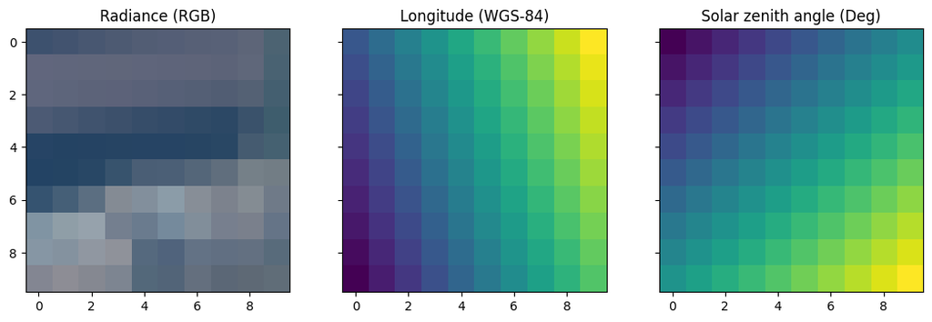

The input image doesn't look like much because this is just a 10x10 pixel example. However we see per-pixel spectral variation in the radiance RGBs, and systematic variation in the location and geometric variables.

```python
# Load the output files
rfl_path = env.path("examples", "image_cube", "small", "output", "ang20170323t202244_rfl")
state_path = env.path("examples", "image_cube", "small", "output", "ang20170323t202244_state")
uncert_path = env.path("examples", "image_cube", "small", "output", "ang20170323t202244_uncert")

rfl = envi.open(envi_header(str(rfl_path)))
state = envi.open(envi_header(str(state_path)))
uncert = envi.open(envi_header(str(uncert_path)))

rfl_im = rfl.open_memmap(interleave='bip')
state_im = state.open_memmap(interleave='bip')
uncert_im = uncert.open_memmap(interleave='bip')

print(f'Shape of the _rfl file: {rfl_im.shape}')
print(f'Shape of the _state file: {state_im.shape}')
print(f'Shape of the _uncert file: {uncert_im.shape}')
```

# Load the output files rfl_path = env.path("examples", "image_cube", "small", "output", "ang20170323t202244_rfl") state_path = env.path("examples", "image_cube", "small", "output", "ang20170323t202244_state") uncert_path = env.path("examples", "image_cube", "small", "output", "ang20170323t202244_uncert") rfl = envi.open(envi_header(str(rfl_path))) state = envi.open(envi_header(str(state_path))) uncert = envi.open(envi_header(str(uncert_path))) rfl_im = rfl.open_memmap(interleave='bip') state_im = state.open_memmap(interleave='bip') uncert_im = uncert.open_memmap(interleave='bip') print(f'Shape of the _rfl file: {rfl_im.shape}') print(f'Shape of the _state file: {state_im.shape}') print(f'Shape of the _uncert file: {uncert_im.shape}')

```
Shape of the _rfl file: (10, 10, 425)
Shape of the _state file: (10, 10, 427)
Shape of the _uncert file: (10, 10, 427)
```

The difference between the `_rfl` file and the `_state` file is that the `_rfl` file only contains the solutions for surface reflectance variables. Here, the AVIRIS-NG image contains 425 wavelength bands. As a result, the `_rfl` contains 425 bands. The `_state` and `_uncert` files contain the surface reflectance solutions and uncertainty calculated as the standard deviation of the posterior distributions for the 425 wavelength bands and for non-reflectance statevector elements; here, aerosol optical depth (AOD) and water vapor (H2O).

```python
# Plot the output data
normalize = lambda x, vmin, vmax:  (x - vmin) / (vmax - vmin)
bands = [55, 35, 15]

fig, axs = plt.subplots(2, 2, sharex=True, sharey=True, figsize=(8, 8))
axs = np.ravel(axs)
plot = axs[0].imshow(normalize(rfl_im[..., bands], 0, 0.3))
uncert = axs[1].imshow(uncert_im[..., 55])
aod = axs[2].imshow(state_im[..., -2])
h2o = axs[3].imshow(state_im[..., -1])

plt.colorbar(uncert)
plt.colorbar(aod)
plt.colorbar(h2o)

title = axs[0].set_title('Reflectance')
title = axs[1].set_title('Uncertainty (at 650 nm)')
title = axs[2].set_title('AOD')
title = axs[3].set_title('H2O')
```

# Plot the output data normalize = lambda x, vmin, vmax: (x - vmin) / (vmax - vmin) bands = [55, 35, 15] fig, axs = plt.subplots(2, 2, sharex=True, sharey=True, figsize=(8, 8)) axs = np.ravel(axs) plot = axs[0].imshow(normalize(rfl_im[..., bands], 0, 0.3)) uncert = axs[1].imshow(uncert_im[..., 55]) aod = axs[2].imshow(state_im[..., -2]) h2o = axs[3].imshow(state_im[..., -1]) plt.colorbar(uncert) plt.colorbar(aod) plt.colorbar(h2o) title = axs[0].set_title('Reflectance') title = axs[1].set_title('Uncertainty (at 650 nm)') title = axs[2].set_title('AOD') title = axs[3].set_title('H2O')

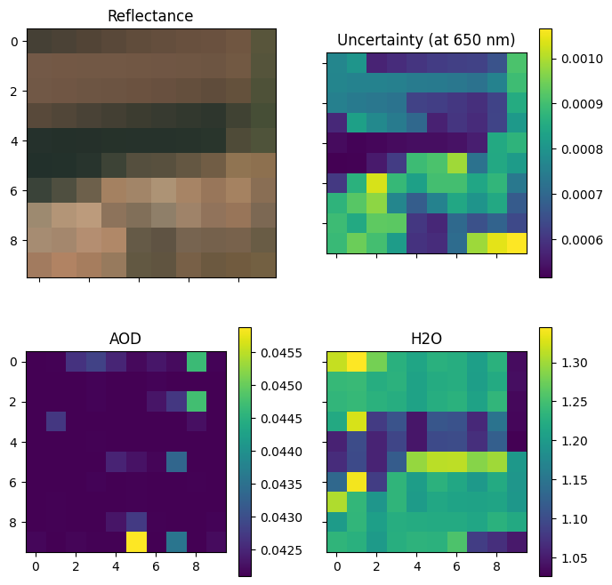

## The Analytical Line

In the example above, we ran Isofit using the full optimal estimation (OE) on each pixel independently. Computationally, this amounts to iterating through each row-column pair to solve for the full state-vector (427 variables in the above case). However for large images, this demands long run-times, and ignores the principle that some state-vector elements, namely the atmospheric variables like AOD and H2O, should not vary from one pixel to another, but rather should be spatially smooth, and only vary over multi-pixel length scales [Link to the relevent paper](https://www.sciencedirect.com/science/article/pii/S0034425723004534/).

The analytical line and empirical line algorithms leverage the assumption of a spatially smooth atmosphere to decrease run times by a factor of 10. Currently, we suggest using the analytical line algorithm and not the empirical line algorithm.

See the following CLI call to run Apply OE with the analytical line algorithm:

```
  IC=$(isofit path examples)/image_cube/medium EX=$(isofit path examples)/image_cube/medium \
  isofit apply_oe \
  $IC/ang20170323t202244_rdn_7k-8k \
  $IC/ang20170323t202244_loc_7k-8k \
  $IC/ang20170323t202244_obs_7k-8k \
  $EX \
  ang \
  --surface_path $EX/configs/surface.json \
  --emulator_base $(isofit path srtmnet --key file) \
  --n_cores 10 \
  --presolve \
  --analytical_line \
  --segmentation_size 50 \
  --log_file $EX/log.txt
```

Most of the input parameters are identical to the per-pixel application above. However, we've added a `--log_file`, the `--analytical_line` flag, and a `--segmentation_size`. The `--log_file` points the program to write a text file to print logging statements during run time. The `--analytical_line` flag tells Isofit to use the analytical line algorithm.

A simple overview for the anylitical line algorithm:

1. All three input files are "segmented" into superpixel blocks using the SLIC algorithm. The `--segmentation_size` value sets the number of pixels that each superpixel contains.
2. At the superpixel resolution, Isofit solves for the OE solutions, which provides both surface and atmospheric state variables.
3. Atmospheric state variables are spatially interpolated to full image resolution. The spatial interpolation uses the Apply OE parameters `--num_neighbors` and `--atm_sigma`.
4. With a fixed atmosphere, we leverage a closed form solution for surface state elements that allows for a solution convergence in a single iteration.

```python
# Alternatively, you can programatically call apply_oe. If you executed apply_oe via the command line above, do not run this
# We use the env object to retrieve the actual location of the ISOFIT extra dependencies instead of assuming where they could be
import os
import shutil

from isofit.utils.apply_oe import apply_oe
from isofit.data import env

output = env.path("examples", "image_cube", "medium")

# Cleanup any previous runs; comment this out if you want to preserve a previous run's output
if (o := output / "output").exists():
    shutil.rmtree(o)

apply_oe(
    input_radiance    = str(env.path("examples", "image_cube", "medium", "data", "ang20170323t202244_rdn_7000-7010")),
    input_loc         = str(env.path("examples", "image_cube", "medium", "data", "ang20170323t202244_loc_7000-7010")),
    input_obs         = str(env.path("examples", "image_cube", "medium", "data", "ang20170323t202244_obs_7000-7010")),
    working_directory = str(output),
    sensor            = "ang",
    surface_path      = str(env.path("examples", "image_cube", "medium", "configs", "surface.json")),
    emulator_base     = str(env.path("srtmnet", key="srtmnet.file")),
    presolve          = True,
    n_cores           = os.cpu_count(),
    analytical_line   = True,
    segmentation_size = 50,
)
```

# Alternatively, you can programatically call apply_oe. If you executed apply_oe via the command line above, do not run this # We use the env object to retrieve the actual location of the ISOFIT extra dependencies instead of assuming where they could be import os import shutil from isofit.utils.apply_oe import apply_oe from isofit.data import env output = env.path("examples", "image_cube", "medium") # Cleanup any previous runs; comment this out if you want to preserve a previous run's output if (o := output / "output").exists(): shutil.rmtree(o) apply_oe( input_radiance = str(env.path("examples", "image_cube", "medium", "data", "ang20170323t202244_rdn_7000-7010")), input_loc = str(env.path("examples", "image_cube", "medium", "data", "ang20170323t202244_loc_7000-7010")), input_obs = str(env.path("examples", "image_cube", "medium", "data", "ang20170323t202244_obs_7000-7010")), working_directory = str(output), sensor = "ang", surface_path = str(env.path("examples", "image_cube", "medium", "configs", "surface.json")), emulator_base = str(env.path("srtmnet", key="srtmnet.file")), presolve = True, n_cores = os.cpu_count(), analytical_line = True, segmentation_size = 50, )

[output not shown]

[output not shown]

[output not shown]

```
INFO:2026-05-20,17:40:55 || apply_oe.py:apply_oe() | Checking input data files...
```

[output not shown]

```
EX=$(isofit path examples)/image_cube/medium isofit reconstruct_subs \
    $EX/input/ang20170323t202244_subs_rdn \
    $EX/input/ang20170323t202244_subs_recon_rdn \
    $EX/output/ang20170323t202244_lbl

EX=$(isofit path examples)/image_cube/medium isofit reconstruct_subs \
    $EX/input/ang20170323t202244_subs_loc \
    $EX/input/ang20170323t202244_subs_recon_loc \
    $EX/output/ang20170323t202244_lbl

EX=$(isofit path examples)/image_cube/medium isofit reconstruct_subs \
    $EX/input/ang20170323t202244_subs_obs \
    $EX/input/ang20170323t202244_subs_recon_obs \
    $EX/output/ang20170323t202244_lbl
```

```python
from isofit.utils.reconstruct import reconstruct_subs

for product in ("rdn", "loc", "obs"):
    reconstruct_subs(
        input_subs_path  = str(env.path("examples", "image_cube", "medium", "input", f"ang20170323t202244_subs_{product}")),
        output_path      = str(env.path("examples", "image_cube", "medium", "input", f"ang20170323t202244_subs_recon_{product}")),
        lbl_working_path = str(env.path("examples", "image_cube", "medium", "output", "ang20170323t202244_lbl")),
    )
```

from isofit.utils.reconstruct import reconstruct_subs for product in ("rdn", "loc", "obs"): reconstruct_subs( input_subs_path = str(env.path("examples", "image_cube", "medium", "input", f"ang20170323t202244_subs_{product}")), output_path = str(env.path("examples", "image_cube", "medium", "input", f"ang20170323t202244_subs_recon_{product}")), lbl_working_path = str(env.path("examples", "image_cube", "medium", "output", "ang20170323t202244_lbl")), )

[output not shown]

[output not shown]

[output not shown]

[output not shown]

```python
# Plotting the input data
rdn_path = env.path("examples", "image_cube", "medium", "data", "ang20170323t202244_rdn_7000-7010")
loc_path = env.path("examples", "image_cube", "medium", "data", "ang20170323t202244_loc_7000-7010")
obs_path = env.path("examples", "image_cube", "medium", "data", "ang20170323t202244_obs_7000-7010")

subs_rdn_path = env.path("examples", "image_cube", "medium", "input", "ang20170323t202244_subs_recon_rdn")
subs_loc_path = env.path("examples", "image_cube", "medium", "input", "ang20170323t202244_subs_recon_loc")
subs_obs_path = env.path("examples", "image_cube", "medium", "input", "ang20170323t202244_subs_recon_obs")

rdn = envi.open(envi_header(str(rdn_path)))
loc = envi.open(envi_header(str(loc_path)))
obs = envi.open(envi_header(str(obs_path)))

subs_rdn = envi.open(envi_header(str(subs_rdn_path)))
subs_loc = envi.open(envi_header(str(subs_loc_path)))
subs_obs = envi.open(envi_header(str(subs_obs_path)))

rdn_im = rdn.open_memmap(interleave='bip')
loc_im = loc.open_memmap(interleave='bip')
obs_im = obs.open_memmap(interleave='bip')

subs_rdn_im = subs_rdn.open_memmap(interleave='bip')
subs_loc_im = subs_loc.open_memmap(interleave='bip')
subs_obs_im = subs_obs.open_memmap(interleave='bip')

fig, axs = plt.subplots(2, 3, sharex=True, sharey=True, figsize=(10, 10))
axs = np.ravel(axs)

axs[0].imshow(normalize(rdn_im[0:400, :, bands], 0, 15))
axs[1].imshow(loc[0:400, :, 0])
axs[2].imshow(obs[0:400, :, 4])

axs[3].imshow(normalize(subs_rdn_im[0:400, :, bands], 0, 15))
axs[4].imshow(subs_loc[0:400, :, 0])
axs[5].imshow(subs_obs[0:400, :, 4])

axs[0].set_title('Radiance')
axs[1].set_title('Longitude')
axs[2].set_title('Elevation')

axs[0].set_ylabel('Full resolution')
axs[3].set_ylabel('Superpixel resolution')
plt.show()
```

[output not shown]

# Plotting the input data rdn_path = env.path("examples", "image_cube", "medium", "data", "ang20170323t202244_rdn_7000-7010") loc_path = env.path("examples", "image_cube", "medium", "data", "ang20170323t202244_loc_7000-7010") obs_path = env.path("examples", "image_cube", "medium", "data", "ang20170323t202244_obs_7000-7010") subs_rdn_path = env.path("examples", "image_cube", "medium", "input", "ang20170323t202244_subs_recon_rdn") subs_loc_path = env.path("examples", "image_cube", "medium", "input", "ang20170323t202244_subs_recon_loc") subs_obs_path = env.path("examples", "image_cube", "medium", "input", "ang20170323t202244_subs_recon_obs") rdn = envi.open(envi_header(str(rdn_path))) loc = envi.open(envi_header(str(loc_path))) obs = envi.open(envi_header(str(obs_path))) subs_rdn = envi.open(envi_header(str(subs_rdn_path))) subs_loc = envi.open(envi_header(str(subs_loc_path))) subs_obs = envi.open(envi_header(str(subs_obs_path))) rdn_im = rdn.open_memmap(interleave='bip') loc_im = loc.open_memmap(interleave='bip') obs_im = obs.open_memmap(interleave='bip') subs_rdn_im = subs_rdn.open_memmap(interleave='bip') subs_loc_im = subs_loc.open_memmap(interleave='bip') subs_obs_im = subs_obs.open_memmap(interleave='bip') fig, axs = plt.subplots(2, 3, sharex=True, sharey=True, figsize=(10, 10)) axs = np.ravel(axs) axs[0].imshow(normalize(rdn_im[0:400, :, bands], 0, 15)) axs[1].imshow(loc[0:400, :, 0]) axs[2].imshow(obs[0:400, :, 4]) axs[3].imshow(normalize(subs_rdn_im[0:400, :, bands], 0, 15)) axs[4].imshow(subs_loc[0:400, :, 0]) axs[5].imshow(subs_obs[0:400, :, 4]) axs[0].set_title('Radiance') axs[1].set_title('Longitude') axs[2].set_title('Elevation') axs[0].set_ylabel('Full resolution') axs[3].set_ylabel('Superpixel resolution') plt.show()

[output not shown]

[output not shown]

[output not shown]

[output not shown]

[output not shown]

[output not shown]

[output not shown]

```python
wl = np.array(rdn.metadata['wavelength']).astype(float)

state_path = str(env.path("examples", "image_cube", "medium", "output", "ang20170323t202244_recon_subs_state"))
reconstruct_subs(
    input_subs_path  = str(env.path("examples", "image_cube", "medium", "output", "ang20170323t202244_subs_state")),
    output_path      = state_path,
    lbl_working_path = str(env.path("examples", "image_cube", "medium", "output", "ang20170323t202244_lbl")),
)

state = envi.open(envi_header(str(state_path)))
state_im = state.open_memmap(interleave='bip')

fig, axs = plt.subplots(1, 4, sharex=True, sharey=True, figsize=(8, 5), tight_layout=True)
axs[0].imshow(normalize(rdn_im[0:400, :, bands], 0, 15))
axs[1].imshow(normalize(state_im[0:400, :, bands], 0, 0.25))
aod = axs[2].imshow(state_im[0:400, :, -2])
h2o = axs[3].imshow(state_im[0:400, :, -1])

plt.colorbar(aod)
plt.colorbar(h2o)

axs[0].set_title('Radiance')
axs[1].set_title('Reflectance')
axs[2].set_title('AOD')
axs[3].set_title('H2O')
plt.show()
```

[output not shown]

wl = np.array(rdn.metadata['wavelength']).astype(float) state_path = str(env.path("examples", "image_cube", "medium", "output", "ang20170323t202244_recon_subs_state")) reconstruct_subs( input_subs_path = str(env.path("examples", "image_cube", "medium", "output", "ang20170323t202244_subs_state")), output_path = state_path, lbl_working_path = str(env.path("examples", "image_cube", "medium", "output", "ang20170323t202244_lbl")), ) state = envi.open(envi_header(str(state_path))) state_im = state.open_memmap(interleave='bip') fig, axs = plt.subplots(1, 4, sharex=True, sharey=True, figsize=(8, 5), tight_layout=True) axs[0].imshow(normalize(rdn_im[0:400, :, bands], 0, 15)) axs[1].imshow(normalize(state_im[0:400, :, bands], 0, 0.25)) aod = axs[2].imshow(state_im[0:400, :, -2]) h2o = axs[3].imshow(state_im[0:400, :, -1]) plt.colorbar(aod) plt.colorbar(h2o) axs[0].set_title('Radiance') axs[1].set_title('Reflectance') axs[2].set_title('AOD') axs[3].set_title('H2O') plt.show()

[output not shown]

[output not shown]

[output not shown]

[output not shown]

```python
rfl_path = env.path("examples", "image_cube", "medium", "output", "ang20170323t202244_rfl")
atm_path = env.path("examples", "image_cube", "medium", "output", "ang20170323t202244_atm_interp")

rfl  = envi.open(envi_header(str(rfl_path)))
atm  = envi.open(envi_header(str(atm_path)))

rfl_im = rfl.open_memmap(interleave='bip')
atm_im = atm.open_memmap(interleave='bip')


fig, axs = plt.subplots(1, 4, sharex=True, sharey=True, figsize=(8, 5), tight_layout=True)
axs[0].imshow(normalize(rdn_im[0:400, :, bands], 0, 15))
axs[1].imshow(normalize(rfl_im[0:400, :, bands], 0, 0.25))
aod = axs[2].imshow(atm_im[0:400, :, -2])
h2o = axs[3].imshow(atm_im[0:400, :, -1])

plt.colorbar(aod)
plt.colorbar(h2o)

axs[0].set_title('Radiance')
axs[1].set_title('Reflectance')
axs[2].set_title('AOD')
axs[3].set_title('H2O')
plt.show()
```

[output not shown]

rfl_path = env.path("examples", "image_cube", "medium", "output", "ang20170323t202244_rfl") atm_path = env.path("examples", "image_cube", "medium", "output", "ang20170323t202244_atm_interp") rfl = envi.open(envi_header(str(rfl_path))) atm = envi.open(envi_header(str(atm_path))) rfl_im = rfl.open_memmap(interleave='bip') atm_im = atm.open_memmap(interleave='bip') fig, axs = plt.subplots(1, 4, sharex=True, sharey=True, figsize=(8, 5), tight_layout=True) axs[0].imshow(normalize(rdn_im[0:400, :, bands], 0, 15)) axs[1].imshow(normalize(rfl_im[0:400, :, bands], 0, 0.25)) aod = axs[2].imshow(atm_im[0:400, :, -2]) h2o = axs[3].imshow(atm_im[0:400, :, -1]) plt.colorbar(aod) plt.colorbar(h2o) axs[0].set_title('Radiance') axs[1].set_title('Reflectance') axs[2].set_title('AOD') axs[3].set_title('H2O') plt.show()

[output not shown]

[output not shown]

[output not shown]